# length of stay in hospital parameterisation

Rob Challen

14 April 2020

```r
knitr::opts_chunk$set(echo = TRUE)
library(tidyverse)
library(lubridate)
devtools::load_all("~/Git/uk-covid-datatools/")
devtools::load_all("~/Git/standard-print-output/")
source("~/Git/uk-covid-datatools/data-raw/rawDataFunctions.R")
library(survival)
library(patchwork)
```

```r
paths=list(
  chess="~/S3/encrypted/15Apr/CHESS COVID19 CaseReport 20200415.csv",
  lineList="~/S3/encrypted/15Apr/Anonymised Line List 20200415.xlsx",
  ff100="~/S3/encrypted/15Apr/Anonymised Line List 20200415.xlsx",
  chessSummary="~/S3/encrypted/15Apr/CHESS Aggregate Report 20200415.csv",
  sitrep="~/S3/encrypted/8Apr/Covid sitrep report incl CIC 20200408 FINAL.xlsx",
  bristol="~/S3/encrypted/AVONCAP_DATA_2020-04-18_1944.csv"
)

ggplot2::theme_set(standardPrintOutput::defaultFigureLayout())
```

```
## Registering fonts with R
```

```r
CHESSClean = getCHESS(paths$chess) %>% cleanseCHESSData("2020-04-15")
```

## Survival model - Admission to outcome

- Excludes hospitals which:
- 1. haven;t updated data from > 3 days
- 2. Have censored outcomes mode than one sd from the mean.
- N.b. This is over half of the hospitals.
- furthermore some other data quality issues e.g. outcome date before admission date
- multiple admissions: just use first admission

```r
admissionToDischargeOrDeath = CHESSClean %>% filter(age>10) %>% generateSurvivalData(
  idVar = caseid,
  startDateVar = hospitaladmissiondate,
  endDateExpr = finaloutcomedate,
  statusExpr = if_else(is.na(finaloutcome),0,1),
  censoredDateExpr = censorDate,
  ageBreaks = c(-Inf,30,60,80,Inf),
  ageLabels = c("10-30","30-60","60-80","80+"),
  ageReferenceCat = "30-60",
  statusLabels = c("censored","discharged/died")
) %>% select(
  caseid, status, trustcode, finaloutcome, time, ageCat, sex
)
```

# summarise data

```r
summary = bind_rows(
  admissionToDischargeOrDeath %>% group_by(value = finaloutcome) %>% summarise(N=n(), `%age`=sprintf("%1.1f %%",n()/nrow(admissionToDischargeOrDeath)*100)) %>% mutate(category="Outcome", value = if_else(is.na(value),"Inpatient",as.character(value))),
  admissionToDischargeOrDeath %>% group_by(value = sex) %>% summarise(N=n(), `%age`=sprintf("%1.1f %%",n()/nrow(admissionToDischargeOrDeath)*100)) %>% mutate(category="Gender", value = as.character(value)),
  admissionToDischargeOrDeath %>% group_by(value = ageCat) %>% summarise(N=n(), `%age`=sprintf("%1.1f %%",n()/nrow(admissionToDischargeOrDeath)*100)) %>% mutate(category="Age", value = as.character(value)) %>% arrange(value),
  admissionToDischargeOrDeath %>% summarise(N=n()) %>% mutate(category="Total", value = "", `%age`="" )
)
summary %>% group_by(category) %>% standardPrintOutput::saveTable("~/Dropbox/covid19/ventilator-demand/parameterisation/admission-to-discharge/Table1_summary")
```

| category | value | N | %age |
| --- | --- | --- | --- |
| Age | 10-30 | 85 | 2.0 % |
|  | 30-60 | 1352 | 31.4 % |
|  | 60-80 | 1835 | 42.6 % |
|  | 80+ | 1039 | 24.1 % |
| Gender | Male | 2719 | 63.1 % |
|  | Female | 1592 | 36.9 % |
| Outcome | Death | 1151 | 26.7 % |
|  | Discharged | 1158 | 26.9 % |
|  | Transfered | 95 | 2.2 % |
|  | Inpatient | 1907 | 44.2 % |
| Total |  | 4311 |  |

# fit a survival model

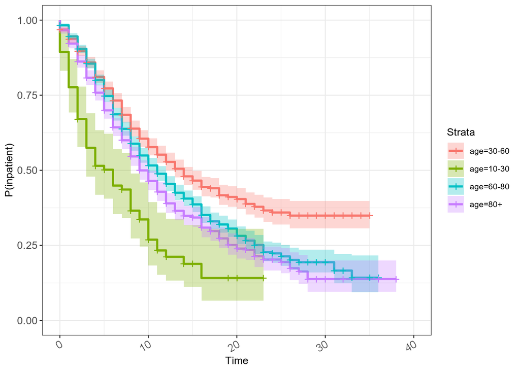

```r
tmpSurv= admissionToDischargeOrDeath %>% rename(age = ageCat) %>% mutate(status = as.integer(status)-1)
fitByAgeCat = survfit(Surv(time,status) ~ age, tmpSurv)
plot = survminer::ggsurvplot(
  fitByAgeCat, conf.int = TRUE
)+ylab("P(inpatient)")

(plot$plot+standardPrintOutput::defaultFigureLayout()) %>%
  standardPrintOutput::saveThirdPageFigure("~/Dropbox/covid19/ventilator-demand/parameterisation/admission-to-discharge/Fig1_kaplanMeierByAge")
```

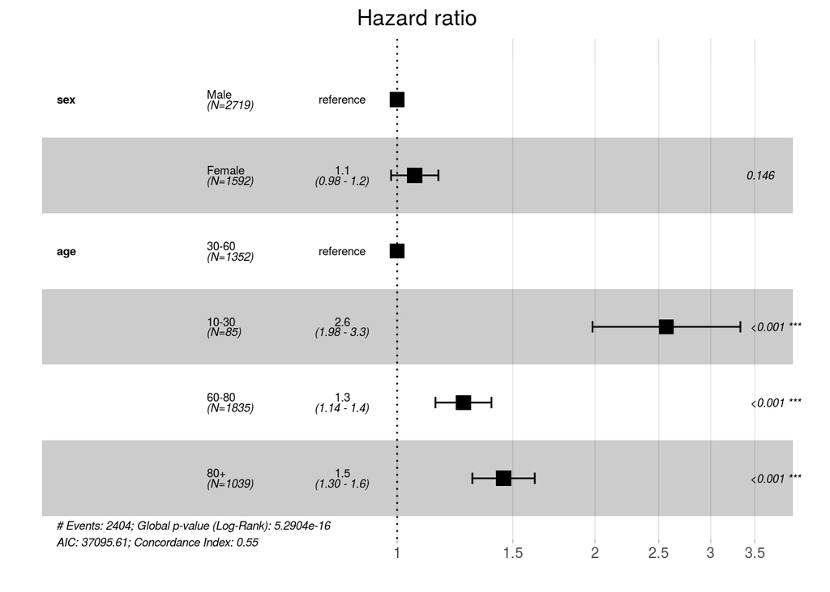

```r
# summary(admissionToDischargeOrDeath)

survModel = coxph(Surv(time,status) ~ sex + age, tmpSurv)
# survModel %>% gtsummary::tbl_regression(exp = TRUE)

survminer::ggforest(survModel ) %>%
  standardPrintOutput::saveThirdPageFigure("~/Dropbox/covid19/ventilator-demand/parameterisation/admission-to-discharge/Fig2_coxModel")
```

Interpretation is that a high HR => discharge or death is more likely - i.e. an inpatient admission is likely to be shorter.

# Parameter fitting

Uses different age bands

```r
censoredAdmissionToDischargeOrDeath = CHESSClean %>% filter(age>15) %>% generateSurvivalData(
  idVar=caseid,
  startDateVar = hospitaladmissiondate,
  endDateExpr = finaloutcomedate,
  statusExpr = if_else(is.na(finaloutcome),0,1),
  statusLabels = c("censored","discharged/died")
) %>% select(
  caseid, status, trustcode, finaloutcome, time, ageCat, sex
)
```

# Parameter fitting goodness of fit test for single age group

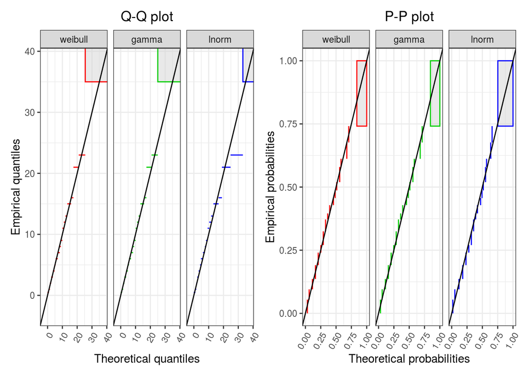

```r
models = c("weibull","gamma","lnorm")

subGroup = censoredAdmissionToDischargeOrDeath %>% filter(ageCat=="40-44") %>% mutate(
    time = if_else(time==0,0.5,time)
  ) %>% mutate(
    left=time,
    right=if_else(status=="censored", as.double(NA), time)
  ) %>% select(left,right) %>% as.data.frame()
dists = suppressWarnings(lapply(models, function(m) fitdistrplus::fitdistcens(subGroup, m)))
p1 = fitdistrplus::qqcompcens(dists, plotstyle = "ggplot") +standardPrintOutput::narrowAndTall()
p2 = fitdistrplus::ppcompcens(dists, plotstyle = "ggplot") +standardPrintOutput::narrowAndTall()
(p1 + p2 + patchwork::plot_layout(ncol=2)) %>% standardPrintOutput::saveQuarterPageFigure("~/Dropbox/covid19/ventilator-demand/parameterisation/admission-to-discharge/Fig3_fitDistributions")
```

# fit all models to all age groups

Log norms seem to fit best for all age groups

```r
out = censoredAdmissionToDischargeOrDeath %>% fitModelsByAge()

out %>% mutate(value = sprintf("%1.4f [%1.4f; %1.4f]", value, low_ci, high_ci)) %>% select(ageCat,n,model,aic,bic,loglik,param, value) %>%
  group_by(ageCat,n,model,aic,bic,loglik) %>% standardPrintOutput::saveTableLandscape("~/Dropbox/covid19/ventilator-demand/parameterisation/admission-to-discharge/SuppTable1_fullBreakdownFittedModels")
```

| ageCat | n | model | aic | bic | loglik | param | value |
| --- | --- | --- | --- | --- | --- | --- | --- |
| 15-19 | 7 | gamma | 29.9 | 29.8 | -12.9 | shape | 0.9411 [-0.0664; 1.9487] |
|  |  |  |  |  |  | rate | 0.1890 [-0.1205; 0.4986] |
|  |  | lnorm | 28.3 | 28.1 | -12.1 | meanlog | 1.0509 [0.0862; 2.0156] |
|  |  |  |  |  |  | sdlog | 1.2308 [0.4109; 2.0507] |
|  |  | weibull | 29.8 | 29.7 | -12.9 | shape | 0.8821 [0.2582; 1.5061] |
|  |  |  |  |  |  | scale | 4.8997 [0.0295; 9.7699] |
| 20-24 | 23 | gamma | 107 | 109 | -51.4 | shape | 0.9394 [0.3801; 1.4987] |
|  |  |  |  |  |  | rate | 0.1011 [0.0079; 0.1944] |
|  |  | lnorm | 103 | 105 | -49.4 | meanlog | 1.6904 [1.1268; 2.2541] |
|  |  |  |  |  |  | sdlog | 1.2917 [0.8103; 1.7730] |
|  |  | weibull | 106 | 109 | -51.2 | shape | 0.8965 [0.5317; 1.2613] |
|  |  |  |  |  |  | scale | 9.1868 [4.1532; 14.2204] |
| 25-29 | 53 | gamma | 256 | 260 | -126 | shape | 0.8883 [0.5626; 1.2141] |
|  |  |  |  |  |  | rate | 0.1085 [0.0490; 0.1681] |
|  |  | lnorm | 253 | 257 | -125 | meanlog | 1.5112 [1.1211; 1.9014] |
|  |  |  |  |  |  | sdlog | 1.3882 [1.0754; 1.7010] |
|  |  | weibull | 256 | 260 | -126 | shape | 0.8996 [0.6716; 1.1275] |
|  |  |  |  |  |  | scale | 7.9232 [5.2221; 10.6243] |
| 30-34 | 63 | gamma | 263 | 267 | -130 | shape | 0.9189 [0.5610; 1.2768] |
|  |  |  |  |  |  | rate | 0.0530 [0.0173; 0.0887] |
|  |  | lnorm | 255 | 260 | -126 | meanlog | 2.3484 [1.9333; 2.7635] |
|  |  |  |  |  |  | sdlog | 1.4177 [1.0526; 1.7828] |
|  |  | weibull | 263 | 267 | -129 | shape | 0.8865 [0.6382; 1.1349] |
|  |  |  |  |  |  | scale | 17.3744 [10.5155; 24.2332] |
| 35-39 | 79 | gamma | 343 | 348 | -170 | shape | 0.6778 [0.4591; 0.8966] |
|  |  |  |  |  |  | rate | 0.0393 [0.0151; 0.0634] |
|  |  | lnorm | 336 | 340 | -166 | meanlog | 2.1440 [1.6911; 2.5969] |
|  |  |  |  |  |  | sdlog | 1.8105 [1.4140; 2.2070] |
|  |  | weibull | 342 | 346 | -169 | shape | 0.7240 [0.5461; 0.9020] |
|  |  |  |  |  |  | scale | 15.7280 [9.3479; 22.1081] |

[output cut: 54 more lines]

# select log normal models

```r
out %>% filter(model=="lnorm") %>% ungroup() %>% mutate(value = sprintf("%1.4f [%1.4f; %1.4f]", value, low_ci, high_ci)) %>%
  select(-low_ci,-high_ci) %>%
  pivot_wider(names_from = param, values_from = value) %>% select(
  -model,-bic,-aic,age=ageCat, N = n, `log(likelihood)`=loglik, `log(mean) [95% CrI]` = meanlog, `log(sd) [95% CrI]` = sdlog
  ) %>% standardPrintOutput::saveTable("~/Dropbox/covid19/ventilator-demand/parameterisation/admission-to-discharge/Table2_logNormalParameterisation")
```

| age | N | log(likelihood) | log(mean) [95% CrI] | log(sd) [95% CrI] |
| --- | --- | --- | --- | --- |
| 15-19 | 7 | -12.1 | 1.0509 [0.0862; 2.0156] | 1.2308 [0.4109; 2.0507] |
| 20-24 | 23 | -49.4 | 1.6904 [1.1268; 2.2541] | 1.2917 [0.8103; 1.7730] |
| 25-29 | 53 | -125 | 1.5112 [1.1211; 1.9014] | 1.3882 [1.0754; 1.7010] |
| 30-34 | 63 | -126 | 2.3484 [1.9333; 2.7635] | 1.4177 [1.0526; 1.7828] |
| 35-39 | 79 | -166 | 2.1440 [1.6911; 2.5969] | 1.8105 [1.4140; 2.2070] |
| 40-44 | 147 | -295 | 2.5069 [2.2057; 2.8081] | 1.5343 [1.2711; 1.7975] |
| 45-49 | 255 | -472 | 2.7483 [2.4979; 2.9987] | 1.5702 [1.3500; 1.7904] |
| 50-54 | 356 | -708 | 2.6343 [2.4728; 2.7959] | 1.2557 [1.1146; 1.3968] |
| 55-59 | 452 | -814 | 2.8058 [2.6455; 2.9661] | 1.3029 [1.1632; 1.4427] |
| 60-64 | 453 | -919 | 2.5496 [2.4164; 2.6828] | 1.1881 [1.0733; 1.3029] |
| 65-69 | 433 | -892 | 2.5114 [2.3698; 2.6530] | 1.2505 [1.1284; 1.3726] |
| 70-74 | 498 | -1.09e+03 | 2.3746 [2.2555; 2.4937] | 1.1806 [1.0786; 1.2825] |
| 75-79 | 451 | -1.04e+03 | 2.1978 [2.0865; 2.3091] | 1.0900 [0.9973; 1.1827] |
| 80+ | 1039 | -2.37e+03 | 2.2355 [2.1511; 2.3199] | 1.2394 [1.1683; 1.3105] |

# generate log normal curves for each age group

- A - “best fit” estimate
- B - low CrI estimate
- C - high CrI estimate

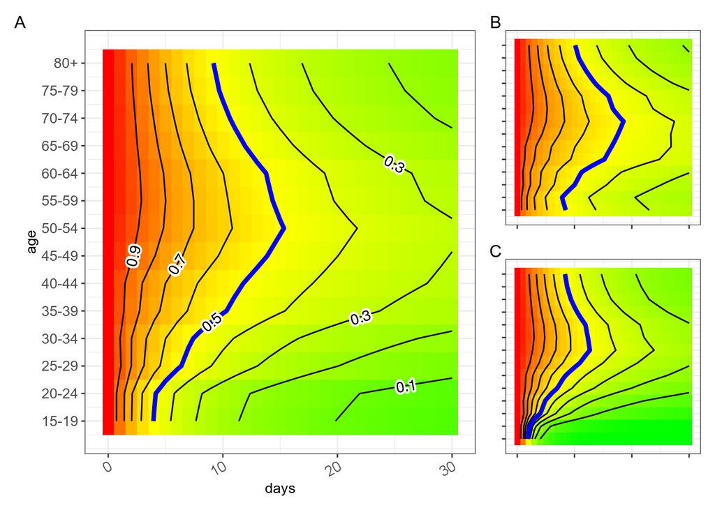

```r
survSurf = out %>% createSurvivalSurfaces()
surf = plotSurvivalSurface(survSurf)
surf %>% standardPrintOutput::saveHalfPageFigure("~/Dropbox/covid19/ventilator-demand/parameterisation/admission-to-discharge/Fig4_losDensity")
```

```r
write.csv(
  survSurf %>% ungroup() %>% mutate(surv = 1-cdf) %>% select(ageCat,days,surv),
  file="~/Dropbox/covid19/ventilator-demand/parameterisation/admission-to-discharge/admission-to-discharge.csv")
```

# incidence surfaces

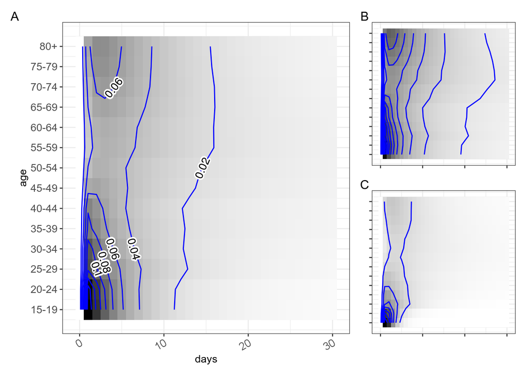

```r
surf2 = plotIncidenceSurface(survSurf)
surf2
```

# validate against Bristol data

Do a set of Kolmogorov-Smirnov tests on different combinations of parameters and log normal distributions

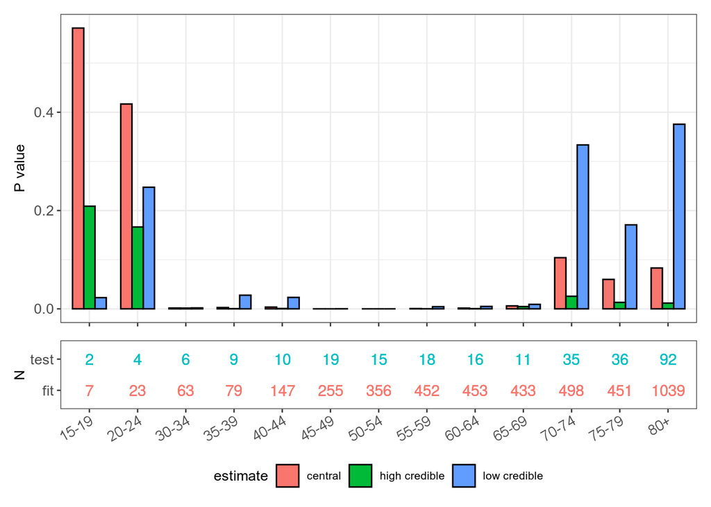

```r
bri = getBristolData(paths$bristol)
bri2 = bri %>% bristolSurvivalSubset()
bri3 = bri2 %>% generateSurvivalData(
  idVar = record_number,
  startDateVar = admission_date,
  endDateExpr = discharge_date,
  statusLabels = c("censored","disch or died")
)

doKSTest = function(d,g,paramNames,params,n) {
  sample = d$time
  params = as.list(params)
  names(params) = paramNames
  params$x = jitter(sample)
  params$y = "plnorm"
  # browser()
  ks = do.call("ks.test",params)
  return(tibble(
    testN = length(sample),
    referenceN = max(n),
    pValue = ks$p.value,
    dStatistic = ks$statistic
  ))
}

gofBri = bri3 %>% filter(status == "disch or died") %>% group_by(ageCat) %>% group_modify(function(d,g,...) {
  reference = out %>% filter(model == "lnorm" & ageCat == g$ageCat)
  out = bind_rows(
    doKSTest(d,g,reference$param, reference$value, reference$n) %>% mutate(estimate = "central"),
    doKSTest(d,g,reference$param, reference$low_ci, reference$n) %>% mutate(estimate = "low credible"),
    doKSTest(d,g,reference$param, reference$high_ci, reference$n) %>% mutate(estimate = "high credible")
  )
})

numbers = gofBri %>% select(ageCat,estimate,test=testN,fit=referenceN) %>% pivot_longer(cols=c("test","fit"),names_to = "source", values_to = "N")

top = ggplot(gofBri, aes(x=ageCat,y=pValue,fill=estimate))+geom_bar(stat="identity", position="dodge", width=0.7, colour="black")+standardPrintOutput::narrowAndTall()+theme(axis.text.x = element_blank(), axis.title.x = element_blank())+ylab("P value")
bottom = ggplot(numbers, aes(x=ageCat,y=source,label=N, colour = source))+geom_text()+guides(colour="none")+theme(panel.grid = element_blank(),axis.title.x = element_blank())+ylab("N")

(top+bottom+patchwork::guide_area()+patchwork::plot_layout(ncol=1, heights = c(9,2,1), guides = "collect")) %>% standardPrintOutput::saveThirdPageFigure("~/Dropbox/covid19/ventilator-demand/parameterisation/admission-to-discharge/Fig5_validateBristol")
```

Possible that my exclusion of hospitals with high numbers of censoring was too enthusiastic, and this would tend to drive down the LOS. Alternatively Bristol OAPs stay longer in hospital as they don’t die as quickly as the rest of the country.